# [ThreadSky](https://tbsky.app/)

A Bluesky thread, unrolled

[figure not shown]

### Randy Herman

@randyhermanlaw.com

I am a lawyer. I am not your lawyer.  
"I have searched the depths of Legal Arguments not yet articulated or vetted."

**13,641** Posts **4,974** Followers **1,153** Following

Hello and welcome on the Terry Sanford Federal Building in beautiful downtown Raleigh, NC where I will be live-posting a show cause hearing starting at 4:00 ET

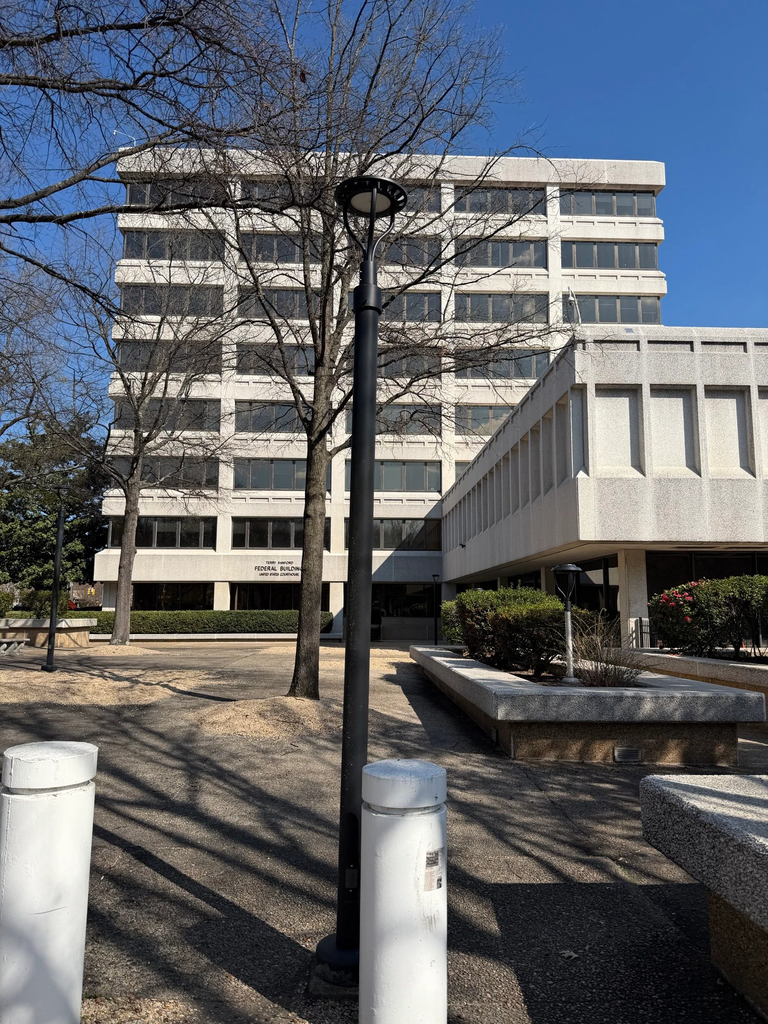

65 222 1123 242

Mar 10 at 2026, 3:55 PM

Background information here:

[figure not shown]

Randy Herman @randyhermanlaw.com

Today at 4:00 I will go over to Raleigh and sit in on a show-cause hearing. This will be my first time attempting to live-post a hearing in person. The case is Fivehouse v. DOD and the question is whether the DOJ attorney fabricated quotes in a brief.

[figure not shown]

##### DOJ Attorney Used Fabricated Quotes in Court Filing (3)

An assistant US attorney in North Carolina filed a response with the court that included “fabricated quotations and misstatements of case holdings” and then made “false or misleading statements” of ho...

news.bloomberglaw.com/us-law-week/federal-prosecutor-used-fabricated-quotes-false-cites-in-filing

10 138 719 27

Mar 10 at 2026, 3:56 PM

This is my first time doing this in-person so it's a bit of an experiment

14 11 496 1

Mar 10 at 2026, 3:56 PM

As attorney I was able to bring my cell phone into the courtroom with me but all photography appears to be strictly forbidden in the building

1 8 427 0

Mar 10 at 2026, 3:58 PM

lol the clerk just said "the hearing starts when the judge comes in, the clock does not matter"

6 14 626 6

Mar 10 at 2026, 3:59 PM

I am obviously not a real reporter, but from looking around I think I may be the only person here who isn't actually involved in the case

6 13 548 1

Mar 10 at 2026, 4:01 PM

All rise

1 3 285 0

Mar 10 at 2026, 4:01 PM

Plaintiff is not here

1 2 290 0

Mar 10 at 2026, 4:02 PM

Neil Fowler and Ellis Boyle here for Mr. Renfer

2 3 274 2

Mar 10 at 2026, 4:03 PM

Judge now reciting the background. Renfer claimed the fabricated citations in this case were inadvertent and the result of accidentally filing an early draft. Upon review of Mr. Renfer's other filings, the court independently discovered other fabrications.

7 76 797 29

Mar 10 at 2026, 4:05 PM

Fowler: we believe this was a solid brief with solid arguments made  
Judge: solid except for the fabricated quotations?

6 107 1082 39

Mar 10 at 2026, 4:06 PM

Boyle: we want to apologize on behalf of the US Attorney's office, this is clearly not acceptable

2 12 450 0

Mar 10 at 2026, 4:06 PM

Boyle: when Plaintiff's surreply was filed it did not appear to be on point and also we have staffing issues

3 12 404 7

Mar 10 at 2026, 4:07 PM

Boyle: DOJ was already investigating this issue before the show-cause order was issued

3 6 343 2

Mar 10 at 2026, 4:08 PM

Boyle handed up what he referred to as a memorandum apparently related to this matter

Judge: this isn't a memorandum  
Boyle: sorry I gave you the wrong document

16 47 813 21

Mar 10 at 2026, 4:09 PM

DOJ not exactly covering itself in glory

5 34 896 7

Mar 10 at 2026, 4:10 PM

Renfer called as witness

2 6 318 0

Mar 10 at 2026, 4:10 PM

Judge: I want to give you an opportunity to explain to the court

Renfer (reading a statement): it was my responsibility to review these citations, I take full responsibility. I failed to complete a full verification. I have practiced law for 30 years. I will never do this again.

5 48 613 9

Mar 10 at 2026, 4:12 PM

Renfer: I did not knowingly make a false representation to the court. As a consequence of this matter I have made the decision to separate from the DOJ.

7 54 647 8

Mar 10 at 2026, 4:13 PM

Judge: thank you for that statement. I still want to give you the opportunity to fully and candidly explain how this happened.  
Render: sorry, what document are we talking about?

Judge now putting the list of errors in front of Renfer

5 34 622 10

Mar 10 at 2026, 4:15 PM

Judge: there are errors in multiple documents. I think the evidence contradicts your statement that this was not done intentionally. Candidly, I need you to give me a full explanation.

4 83 890 22

Mar 10 at 2026, 4:15 PM

Judge reading out the real case quotes and comparing them to the quotes in the filed briefs

2 20 469 3

Mar 10 at 2026, 4:16 PM

Renfer: I accidentally deleted my original brief because I was overwhelmed so I used AI to try and replicate my prior work

28 134 1096 100

Mar 10 at 2026, 4:17 PM

I 100% knew that AI would be the culprit here

12 50 1456 11

Mar 10 at 2026, 4:18 PM

Renfer: I could swear that I had reviewed the document before filing it

5 15 451 3

Mar 10 at 2026, 4:18 PM

DOJ attorneys having a little conference about this at their table

2 10 414 1

Mar 10 at 2026, 4:19 PM

Basically Renfer says he was overwhelmed with documents, he accidentally overwrote his document, he tried to use AI to fix it and AI messed it up

10 31 577 16

Mar 10 at 2026, 4:19 PM

Judge continues to go through each citation pointing out the errors. Renfer claims the same explanation for every error.

1 24 527 1

Mar 10 at 2026, 4:20 PM

Judge now moving on to other filings with other errors, which are obviously not affected by the same "I accidentally overwrote my file" explanation

7 49 769 5

Mar 10 at 2026, 4:21 PM

Judge pointing out that all of the fabricated quotes lean in the same direction (restricting the court's review) which tends to indicate that this was done to deceive the court

7 109 1111 13

Mar 10 at 2026, 4:23 PM

Renfer claiming an error on a different document was the result of a cut-paste error (he cut and pasted language from one case but forget to correct the citation which he had previously written for a different case)

Judge does not like this explanation

7 28 737 4

Mar 10 at 2026, 4:24 PM

On another document: Renfer claims that language he placed in quotation marks was intended as a general statement of the case and not an actual quotation. "This was a writing technique to liven up the prose."

29 64 904 94

Mar 10 at 2026, 4:26 PM

Renfer: the language in quotes was for emphasis, obviously I did not do it correctly

10 12 526 11

Mar 10 at 2026, 4:27 PM

Judge is not impressed

5 33 705 5

Mar 10 at 2026, 4:27 PM

Judge: the challenge is, when you file something with the court that is not forthright, it makes me question everything else you say

4 60 904 16

Mar 10 at 2026, 4:28 PM

Renfer seems pretty unclear about the actual sequence of events he is claiming

1 12 483 0

Mar 10 at 2026, 4:29 PM

Judge: your surreply claims these quotations were "inadvertently included". What do you mean by that?

Renfer: I mean that I thought I had reviewed the document and checked the citations but I guess I didn't

8 21 578 3

Mar 10 at 2026, 4:30 PM

Judge: you intentionally drafted this with AI and you intentionally filed it with the court without checking it. How is this accidental? Why weren't you candid with the court?

4 101 1027 26

Mar 10 at 2026, 4:31 PM

Judge: attorneys, and particularly those with the awesome power of the US Attorney's office, have a responsibility to be candid

2 30 696 2

Mar 10 at 2026, 4:32 PM

Renfer: the issue is whether I tried to deceive the court. I didn't intentionally deceive the court. I just made a mistake.

16 15 412 7

Mar 10 at 2026, 4:33 PM

Renfer: the document I filed was intended to be a draft. Once I came back from my vacation I did the final document.

Judge: you're going to have to walk me through that. I understand the meaning of the words you are saying but it doesn't make any sense.

18 98 1200 72

Mar 10 at 2026, 4:35 PM

Judge gets Renfer to admit he is aware of the many AI hallucination cases

1 24 639 0

Mar 10 at 2026, 4:35 PM

Judge: have you used Gen AI to draft other documents that you have filed in this court?